# Soft Covering and Channel Resolvability

Soft Covering and Channel Resolvability

From Random Coding to Covertness, Secure Sensing, Channel Synthesis, and Watermarking

Tutorial · November 2026

Sidong Guo

School of Electrical and Computer Engineering, Georgia Institute of Technology

Ph.D. student at Georgia Tech · Visiting Research Fellow at Harvard University

[figure not shown]

## Overview: One Lemma, Four Applications

Reliability asks whether a receiver can tell codewords apart. Resolvability asks whether anyone can tell the code from i.i.d. noise.

**Soft covering**

Part I · the lemma

a random codebook of rate $> \I(X;Z)$ makes the channel output look i.i.d.

aim at a covert process

**Covert communication**

Part II · Bloch [12]

random coding over low-weight sequences; $\Theta(\sqrt n)$ bits hidden in noise

the eavesdropper also senses

**Secure ISAC**

Part III · Guo–Bloch [15]

resolvability hides the state-dependent codebook from a sensing eavesdropper

simulate a joint law

**Channel synthesis**

Part IV · Cuff [5]

likelihood encoder + two soft-covering lemmas

add encoder state

**LLM watermarking**

Part V · ITW ’26 [22]

distribution-preserving watermarking is synthesis with state

**One template throughout**: split the codebook index into parts the receiver decodes (packing) and parts that only need to look random (covering).

[5] P. Cuff, “Distributed Channel Synthesis,” *IEEE Trans. Inf. Theory*, 2013. [12] M. R. Bloch, “Covert Communication over Noisy Channels: A Resolvability Perspective,” *IEEE Trans. Inf. Theory*, 2016.  
[15] S. Guo, M. R. Bloch, “Secure Integrated Sensing and Communication against Communication and Sensing Eavesdropping,” arXiv:2601.23216, 2026.  
[22] S. Guo, T. Kann, T. Baluta, M. R. Bloch, “Covert Multi-bit LLM Watermarking: An Information Theory and Coding Approach,” IEEE ITW, 2026.

Part I

Soft Covering and Channel Resolvability

How large must a random codebook be so that its output looks i.i.d.?

## Foundations: Two Questions About One Random Codebook

Soft covering Covert Secure ISAC Synthesis Watermarking $X$: input · $Y$: legitimate output · $Z$: observer output

Codebook $\mathcal C = \{X^n(1), \dots, X^n(M)\}$ drawn i.i.d. from $P_X^{\otimes n}$, $M = 2^{nR}$, one codeword sent through a memoryless channel.

Reliability: packing

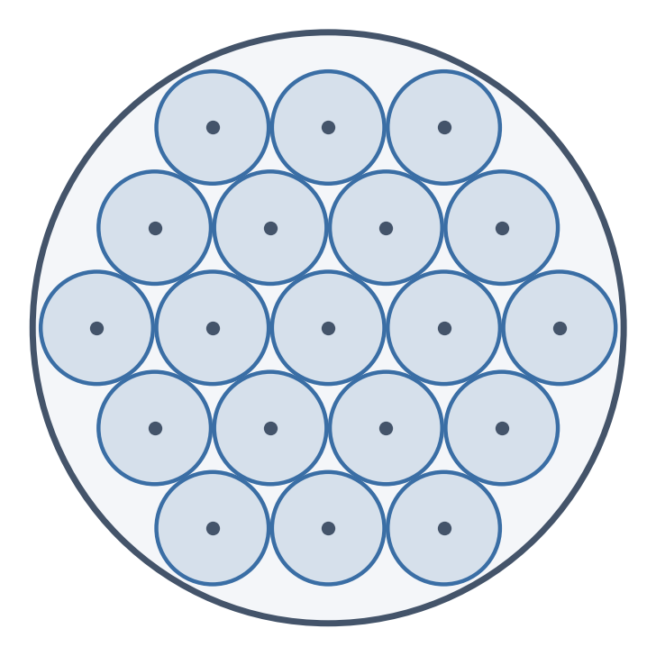

each codeword owns $\approx 2^{n\Hent(Y|X)}$ outputs; disjoint clouds fit  
$2^{nR}\, 2^{n\Hent(Y|X)} \le 2^{n\Hent(Y)} \;\Rightarrow\; R < \I(X;Y)$

Resolvability: covering

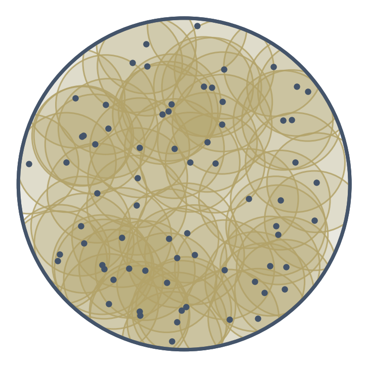

clouds must blanket the $\approx 2^{n\Hent(Z)}$ typical outputs  
$2^{nR}\, 2^{n\Hent(Z|X)} \ge 2^{n\Hent(Z)} \;\Rightarrow\; R > \I(X;Z)$

|  | reliability | resolvability |
| --- | --- | --- |
| question | can the receiver tell codewords apart? | can an observer tell the code from i.i.d. noise? |
| metric | error probability $\Prob(\hat M \neq M)$ | $\V$ or $\D$ between $P_{Z^n \vert \mathcal C}$ and $Q_Z^{\otimes n}$ |
| rate | codebook small enough: $R < \I(X;Y)$ | codebook large enough: $R > \I(X;Z)$ |

## Foundations: Random Coding for Reliability

Soft covering Covert Secure ISAC Synthesis Watermarking $X$: input · $Y$: legitimate output · $Z$: observer output

Let $\imath(x;y) \triangleq \log \frac{W_{Y|X}(y|x)}{Q_Y(y)}$ be the information density, $Q_Y = P_X \circ W_{Y|X}$. For $M$ codewords i.i.d. $P_X$ and the threshold decoder “output the unique $m$ with $\imath(x(m);y) > \log M + \gamma$”, for every $\gamma > 0$
$$\E_{\mathcal C}[P_e] \;\le\; \Prob\big[\imath(X;Y) \le \log M + \gamma\big] + e^{-\gamma}.$$

The sent codeword misses the threshold with probability $\Prob[\imath(X;Y) \le \log M + \gamma]$. A wrong codeword $\bar X$ is independent of $Y$, and a change of measure gives
$$\Prob\big[\imath(\bar X;Y) > \theta\big] = \E_{P_{XY}}\big[e^{-\imath(X;Y)}\, \indicator\{\imath(X;Y) > \theta\}\big] \le e^{-\theta}.$$
A union bound over the $M - 1$ wrong codewords with $\theta = \log M + \gamma$ contributes at most $(M-1)\,e^{-\log M - \gamma} \le e^{-\gamma}$.

- **Asymptotics**: $\imath(X^n;Y^n) = \sum_{i} \imath(X_i;Y_i)$ concentrates at $n\I(X;Y)$, so with $\log M = nR$ and $\gamma = n\epsilon$, $\;P_e \to 0$ whenever $R < \I(X;Y) - \epsilon$
- **Error event**: a *lower* tail of the information density (the codebook is too large to pack)

[1] C. E. Shannon, “Certain Results in Coding Theory for Noisy Channels,” *Information and Control*, 1957.

## Foundations: Random Coding for Resolvability

Soft covering Covert Secure ISAC Synthesis Watermarking $X$: input · $Y$: legitimate output · $Z$: observer output

ideal

\(X^n \sim P_X^{\otimes n}\)

\(W_{Z|X}^{\otimes n}\)

\(Z^n \sim Q_Z^{\otimes n}\)

\(M\)

uniform

codebook \(\mathcal C\)

\(M\) codewords, i.i.d. \(P_X^{\otimes n}\)

\(X^n(M)\)

\(W_{Z|X}^{\otimes n}\)

\(Z^n \sim P_{Z^n|\mathcal C}\)

close in \(\V\) or \(\D\)?

with \(M\) as small as possible

$$P_{Z^n|\mathcal C}(z^n) = \frac{1}{M}\sum_{m=1}^{M} W_{Z|X}^{\otimes n}\big(z^n \mid X^n(m)\big)
\quad \text{replaces} \quad
Q_Z^{\otimes n}(z^n) = \sum_{x^n} P_X^{\otimes n}(x^n)\, W_{Z|X}^{\otimes n}(z^n \mid x^n)$$

$R$ is achievable if some $(M_n, n)$ codes have $\limsup_n \frac1n \log M_n \le R$ and $\delta\big(P_{Z^n|\mathcal C_n}, Q_Z^{\otimes n}\big) \to 0$, $\delta \in \{\V, \D\}$; the channel resolvability is the infimum of such $R$. For a DMC [25, Thm. 3.3.7]
$$C_r(W_{Z|X}, P_X) = \min_{P_{\tilde X}:\; P_{\tilde X} \circ W_{Z|X} = Q_Z} \I(\tilde X; \tilde Z),
\qquad = \I(X;Z) \text{ if } P_X \text{ is the only input that induces } Q_Z.$$

- **Input law fixed**: the least randomness for a *given* output; the worst input gives Han–Verdú’s resolvability, the capacity [3]

[3] T. S. Han, S. Verdú, “Approximation Theory of Output Statistics,” *IEEE Trans. Inf. Theory*, 1993. [25] M. R. Bloch, *Information-Theoretic Security*, draft v0.23, 2020, Sec. 3.3, Fig. 3.5.

## Foundations: Why $2^{n\I(X;Z)}$ Codewords Cover

Soft covering Covert Secure ISAC Synthesis Watermarking $X$: input · $Y$: legitimate output · $Z$: observer output

[figure not shown]

\(\mathcal X^n\)

\(\mathcal Z^n\)

\(x^n(m)\)

cloud of \(x^n(m)\): \(\approx 2^{n\Hent(Z|X)}\)

typical set

\(\approx 2^{n\Hent(Z)}\)

Redrawn from [25, Fig. 3.6]: dots are codewords, dashed discs their conditionally typical clouds, the shaded disc the typical set of $Q_Z^{\otimes n}$

- **Target**: by the AEP, $Q_Z^{\otimes n}$ is nearly uniform on its typical set, $\approx 2^{n\Hent(Z)}$ sequences
- **One codeword**: $W_{Z|X}^{\otimes n}(\cdot \mid x^n(m))$ is nearly uniform on a cloud of $\approx 2^{n\Hent(Z|X)}$ sequences
- **Counting**: the clouds blanket the typical set only if $M \gtrsim 2^{n\Hent(Z)}/2^{n\Hent(Z|X)} = 2^{n\I(X;Z)}$
- **Why “soft”**: a typical $z^n$ lies in $N(z^n) \sim \mathrm{Bin}\big(M, 2^{-n\I(X;Z)}\big)$ clouds, and $P_{Z^n|\mathcal C}(z^n) \approx N(z^n)\, 2^{-n\Hent(Z|X)}/M$, so
  $$\frac{\mathrm{std}\; P_{Z^n|\mathcal C}(z^n)}{Q_Z^{\otimes n}(z^n)} \approx \frac{1}{\sqrt{\E N(z^n)}} = \sqrt{\frac{2^{n\I(X;Z)}}{M}}$$
- **Same threshold, stronger demand** than the covering lemma of lossy compression: every typical output must be hit by *exponentially many* clouds so that $N(z^n)$ concentrates, not merely by one

[25] M. R. Bloch, *Information-Theoretic Security: A Unified Treatment of Information-Theoretic Primitives and Algorithms*, draft v0.23, 2020, Sec. 3.3.2.

## Foundations: Soft Covering, Visually

Soft covering Covert Secure ISAC Synthesis Watermarking $X$: input · $Y$: legitimate output · $Z$: observer output

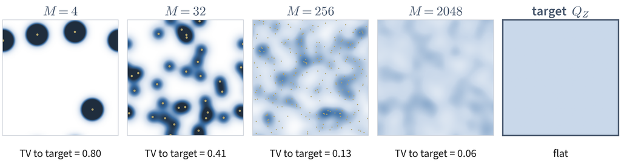

Toy picture on the unit torus: each codeword spreads a noise cloud; the mixture of $M$ clouds flattens toward the target as $M$ grows.

- **Fluctuation term, measured**: from $M = 32$ on, each $8\times$ more codewords cuts the TV by roughly $\sqrt 8 \approx 2.8$, the $1/\sqrt M$ law predicted by the cloud count
- **Why it matters**: an observer who cannot tell the code from i.i.d. noise learns nothing about the index (secrecy) or about whether anything was sent (covertness), and sees the target law (synthesis)

## Foundations: A One-Shot Lemma for Resolvability

Soft covering Covert Secure ISAC Synthesis Watermarking $\imath(x;z) = \log \frac{W_{Z|X}(z|x)}{Q_Z(z)}$ · $\mathcal C_\gamma = \{\imath \le \gamma\}$

Any $P_X$ and $W_{Z|X}$ (one channel use, arbitrary alphabets); $M$ codewords i.i.d. $P_X$, used uniformly; typical pairs $\mathcal C_\gamma \triangleq \{(x,z): \imath(x;z) \le \gamma\}$. For every $\gamma > 0$,
$$\begin{aligned}
\text{(a)}\quad \E_{\mathcal C}\, \V\big(P_{Z|\mathcal C}, Q_Z\big) &\le \Prob\big[(X,Z) \notin \mathcal C_\gamma\big] + \tfrac12\sqrt{e^\gamma/M},\\
\text{(b)}\quad \E_{\mathcal C}\, \D\big(P_{Z|\mathcal C} \,\|\, Q_Z\big) &\le \Prob\big[(X,Z) \notin \mathcal C_\gamma\big]\, \log\big(1/\mu_Z + 1\big) + e^\gamma/M,
\qquad \mu_Z \triangleq \min_{z \in \mathrm{supp}\, Q_Z} Q_Z(z).
\end{aligned}$$

**(a)** Every codeword simulates the target on average, $\E[W_{Z|X}(z|X_m)] = Q_Z(z)$, so $\E P_{Z|\mathcal C} = Q_Z$. Split each cloud at the threshold, $P_{Z|\mathcal C} = P^{(1)} + P^{(2)}$, where $P^{(1)}(z) = \frac1M\sum_m W_{Z|X}(z|X_m)\,\indicator\{(X_m,z) \notin \mathcal C_\gamma\}$ keeps the atypical pairs and $P^{(2)}$ the typical ones. By the triangle inequality,
$$\E\,\V \le \tfrac12\textstyle\sum_z \E\big|P^{(1)}(z) - \E P^{(1)}(z)\big| + \tfrac12\sum_z \E\big|P^{(2)}(z) - \E P^{(2)}(z)\big|.$$
*Atypical part*: $\frac12\E|A - \E A| \le \E A$ for $A \ge 0$, so the first sum is at most $\sum_z \E P^{(1)}(z) = \Prob[(X,Z) \notin \mathcal C_\gamma]$.

*Typical part*: $\E|A - \E A| \le \sqrt{\mathrm{Var}\,A}$ (Jensen), and on $\mathcal C_\gamma$ we have $W_{Z|X}(z|x) \le e^\gamma Q_Z(z)$, so
$$\mathrm{Var}\,P^{(2)}(z) \le \tfrac1M\,\E\big[W_{Z|X}(z|X)^2\,\indicator\{(X,z) \in \mathcal C_\gamma\}\big] \le \tfrac{e^\gamma}{M}\, Q_Z(z)\, \E\big[W_{Z|X}(z|X)\big] = \tfrac{e^\gamma}{M}\, Q_Z(z)^2,$$
and the second sum is at most $\frac12\sum_z \sqrt{e^\gamma/M}\; Q_Z(z) = \frac12\sqrt{e^\gamma/M}$.

[5] P. Cuff, “Distributed Channel Synthesis,” *IEEE Trans. Inf. Theory*, 2013. [25] M. R. Bloch, *Information-Theoretic Security*, draft v0.23, 2020, Lemmas 3.3.2 and 3.3.3.

## Foundations: One-Shot Lemma: The Divergence Bound

Soft covering Covert Secure ISAC Synthesis Watermarking $\imath(x;z) = \log \frac{W_{Z|X}(z|x)}{Q_Z(z)}$ · $\mathcal C_\gamma = \{\imath \le \gamma\}$

**(b)** By symmetry, codeword $X_1$ is sent, so $Z \sim W_{Z|X}(\cdot \mid X_1)$ and $\;\E_{\mathcal C}\, \D(P_{Z|\mathcal C} \,\|\, Q_Z) = \E\Big[\log \frac{1}{M}\sum_{m=1}^{M} e^{\imath(X_m;Z)}\Big]$.

*Jensen* over $X_2, \dots, X_M$, which are independent of $(X_1, Z)$ and satisfy $\E\big[e^{\imath(X_m;Z)} \mid Z\big] = 1$:
$$\E_{\mathcal C}\, \D(P_{Z|\mathcal C} \,\|\, Q_Z) \le \E\Big[\log\Big(\frac{e^{\imath(X_1;Z)}}{M} + \frac{M-1}{M}\Big)\Big] \le \E\Big[\log\Big(1 + \frac{e^{\imath(X;Z)}}{M}\Big)\Big]. \qquad (\star)$$
*Split* $(\star)$ on $\mathcal C_\gamma$: on typical pairs, $\log(1 + e^{\gamma}/M) \le e^\gamma/M$; on atypical pairs, $e^{\imath} = W_{Z|X}/Q_Z \le 1/\mu_Z$, so the integrand is at most $\log(1/\mu_Z + 1)$.

- **Caveat** [25]: the bound is void when $\mu_Z = 0$ (e.g., Gaussian outputs); working directly with $(\star)$ avoids $\mu_Z$
- **Exponent from $(\star)$** [4]: $\log(1 + x) \le x^s/s$ for $s \in (0, 1]$, and $\E\big[e^{s\,\imath(X;Z)}\big] = e^{s\,\D_{1+s}(P_{XZ}\|P_X Q_Z)}$ is multiplicative over letters, so
  $$\E_{\mathcal C}\, \D\big(P_{Z^n|\mathcal C} \,\big\|\, Q_Z^{\otimes n}\big) \le \frac{1}{s}\exp\Big(-ns\big[R - \D_{1+s}(P_{XZ} \| P_X Q_Z)\big]\Big) \longrightarrow 0
  \quad \text{if } R > \I(X;Z),$$
  since the Rényi divergence $\D_{1+s} \downarrow \I(X;Z)$ as $s \downarrow 0$

[4] M. Hayashi, “General Nonasymptotic and Asymptotic Formulas in Channel Resolvability and Identification Capacity and Their Application to the Wiretap Channel,” *IEEE Trans. Inf. Theory*, 2006. [25] M. R. Bloch, *Information-Theoretic Security*, draft v0.23, 2020, Lemma 3.3.3, Prop. 3.3.8.

## Foundations: The Soft-Covering Lemma

Soft covering Covert Secure ISAC Synthesis Watermarking $\imath(x;z) = \log \frac{W_{Z|X}(z|x)}{Q_Z(z)}$

Let $\mathcal C = \{X^n(m)\}_{m=1}^{M}$, $M = e^{nR}$, be i.i.d. $P_X^{\otimes n}$, sent through a DMC $W_{Z|X}$ with $Q_Z = P_X \circ W_{Z|X}$. If $R > \I(X;Z)$, then for some $\beta > 0$
$$\E_{\mathcal C}\, \D\big(P_{Z^n|\mathcal C} \,\big\|\, Q_Z^{\otimes n}\big) \le e^{-n\beta}
\qquad \text{and} \qquad
\E_{\mathcal C}\, \V\big(P_{Z^n|\mathcal C}, Q_Z^{\otimes n}\big) \le e^{-n\beta}.$$

Apply Lemma 2 to $\big(P_X^{\otimes n}, W_{Z|X}^{\otimes n}\big)$ with $\gamma = n(\I(X;Z) + \epsilon)$ and $R > \I(X;Z) + \epsilon$. The density $\imath(X^n;Z^n) = \sum_i \imath(X_i;Z_i)$ is a sum of i.i.d. bounded terms with mean $\I(X;Z)$, so $\Prob[\imath(X^n;Z^n) > \gamma] \le e^{-2n\epsilon^2/b^2}$ by Hoeffding ($b$: range of $\imath$). Also $e^\gamma/M = e^{-n(R - \I(X;Z) - \epsilon)}$, and $\log(1/\mu_Z^n + 1) \le n\log(1/\mu_Z) + 1$ grows only linearly.

|  | Reliability, Lemma 1 | Resolvability, Lemma 2(a) |
| --- | --- | --- |
| codebook | small enough that clouds are disjoint | large enough that clouds overlap many times |
| one-shot bound | \(\Prob[\imath(X;Y) \le \log M + \gamma] + e^{-\gamma}\) | \(\Prob[\imath(X;Z) \gt \log M - \gamma] + \tfrac12 e^{-\gamma/2}\) (threshold \(\log M - \gamma\)) |
| failure | lower tail of \(\imath\) reaches \(\log M\) | upper tail of \(\imath\) reaches \(\log M\) |
| \(n\) letters | \(R \lt \I(X;Y)\) | \(R \gt \I(X;Z)\), optimal by the converse [25, Prop. 3.3.5] |

[2] A. D. Wyner, “The Common Information of Two Dependent Random Variables,” *IEEE Trans. Inf. Theory*, 1975. [3] T. S. Han, S. Verdú, “Approximation Theory of Output Statistics,” *IEEE Trans. Inf. Theory*, 1993.  
[4] M. Hayashi, *IEEE Trans. Inf. Theory*, 2006. [5] P. Cuff, *IEEE Trans. Inf. Theory*, 2013. [25] M. R. Bloch, *Information-Theoretic Security*, draft v0.23, 2020, Prop. 3.3.4.

## Foundations: Soft Covering on a Binary Symmetric Channel

Soft covering Covert Secure ISAC Synthesis Watermarking $X$: input · $Y$: legitimate output · $Z$: observer output

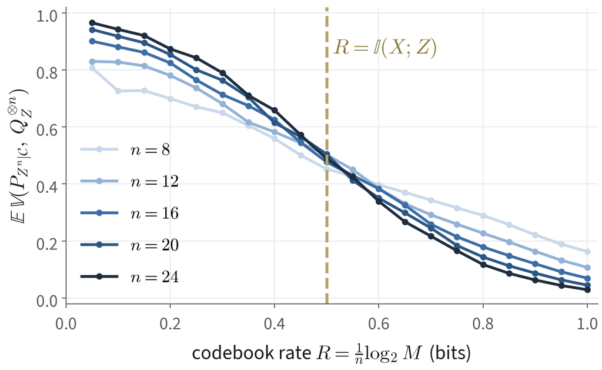

- **Setup**: $X^n$ uniform on $\{0,1\}^n$, BSC with crossover $0.11$, so $\I(X;Z) = 0.50$ bit and $Q_Z^{\otimes n}$ is uniform
- **Exact computation**: $P_{Z^n|\mathcal C}$ is the empirical codeword law convolved with the noise, computed with a Walsh–Hadamard transform for $n \le 24$, averaged over random codebooks
- **Threshold at $\I(X;Z)$**, as Corollary 1 predicts: below it TV $\to 1$, above it TV $\to 0$; the curves cross near $R = \I(X;Z)$ and steepen as $n$ grows, with transition width $\propto 1/\sqrt{n}$ (the spread of $\imath(X^n;Z^n)$, the first term of Lemma 2)

## Foundations: Refinements Used Later

Soft covering Covert Secure ISAC Synthesis Watermarking $\imath(x;z) = \log \frac{W_{Z|X}(z|x)}{Q_Z(z)}$

| Refinement | Statement | Used in |
| --- | --- | --- |
| low weight [12] | Lemma 2(b) with target \(Q_{\alpha_n}^{\otimes n}\); \(\imath\) concentrates at scale \(n\alpha_n\) instead of \(n\) | covert communication (Part II) |
| exponents [4, 7, 8] | \(\E\D \le \tfrac1s e^{-ns[R - \D_{1+s}(P_{XZ}\Vert P_X Q_Z)]}\); exact TV exponent \(E_{\SC}\) [8] | secure ISAC (Part III) |
| high probability [6] | \(\Prob_{\mathcal C}\big[\V \gt \E\V + t\big] \le e^{-2Mt^2}\): doubly exponential in \(n\) | semantic secrecy, watermarking (Part V) |
| indexed codebooks [5] | codewords \(u^n(m,k)\); cover with all indices, or with one row \(k\) | synthesis (IV), watermarking (V) |

- **High probability** [6]: replacing one codeword moves $\V$ by at most $1/M$, so McDiarmid’s inequality [9] gives
  $$\Prob_{\mathcal C}\Big[\V\big(P_{Z^n|\mathcal C}, Q_Z^{\otimes n}\big) > \E_{\mathcal C}\V + t\Big] \le e^{-2Mt^2}
  \qquad \big(M = e^{nR},\; t = e^{-n\gamma'}:\; \text{doubly exponential}\big)$$
  - a union bound over exponentially many messages or states keeps **one** codebook good for **every** index: semantic secrecy

[4] M. Hayashi, *IEEE Trans. Inf. Theory*, 2006. [5] P. Cuff, “Distributed Channel Synthesis,” *IEEE Trans. Inf. Theory*, 2013. [6] P. Cuff, “A Stronger Soft-Covering Lemma and Applications,” IEEE CNS Workshops, 2015.  
[7] M. B. Parizi, E. Telatar, N. Merhav, *IEEE Trans. Inf. Theory*, 2017. [8] S. Yagli, P. Cuff, “Exact Soft-Covering Exponent,” *IEEE Trans. Inf. Theory*, 2019. [9] C. McDiarmid, “On the Method of Bounded Differences,” 1989. [12] M. R. Bloch, *IEEE Trans. Inf. Theory*, 2016.

## Foundations: From Resolvability to Secrecy by Splitting the Index

Soft covering Covert Secure ISAC Synthesis Watermarking $X$: input · $Y$: legitimate output · $Z$: observer output

[figure not shown]

local randomness \(r\), rate \(R'\)

message \(m\), rate \(R\)

- **Wiretap channel** [10]: Bob sees $Y$, Eve sees $Z$; index the codebook by $(m, r)$, with $r$ uniform and known to nobody
- **Row $m$ is covered**: $2^{nR'}$ codewords with $R' > \I(X;Z)$, so $P_{Z^n|M=m} \approx Q_Z^{\otimes n}$ for every $m$ and
  $$\I(M;Z^n) \le \E_M\, \D\big(P_{Z^n|M} \,\big\|\, Q_Z^{\otimes n}\big) \le e^{-n\beta}$$
- **The grid is decoded**: $R + R' < \I(X;Y)$, so Bob recovers $(m, r)$
- **Strong secrecy** at every $R < \I(X;Y) - \I(X;Z)$ [11]

**Index splitting**: some indices are decoded, some are only covered. Every application in this tutorial is a choice of which indices play which role.

[10] A. D. Wyner, “The Wire-Tap Channel,” *Bell Syst. Tech. J.*, 1975. [11] M. R. Bloch, J. N. Laneman, “Strong Secrecy From Channel Resolvability,” *IEEE Trans. Inf. Theory*, 2013.

Part II

Covert Communication

Resolvability with codewords of vanishing weight

## Covert Communication: Model and the Square-Root Law

Soft covering Covert Secure ISAC Synthesis Watermarking $X$: input, $0$ = innocent · $Y$: Bob · $Z$: Willie

\(M\)

Alice

\(X^n\)

\(W_{YZ|X}\)

\(Y^n\)

Bob

decodes \(\hat M\)

\(Z^n\)

Willie

is Alice talking?

secret key \(K\)

- **Binary input**, $x = 0$ is the innocent symbol; $P_x \triangleq W_{Y|X=x}$ at Bob, $Q_x \triangleq W_{Z|X=x}$ at Willie
- **Covertness**: Willie’s code-induced law $\widehat Q^n$ satisfies $\D\big(\widehat Q^n \,\big\|\, Q_0^{\otimes n}\big) \le \delta$, so every test has
  $$P_{\mathrm{FA}} + P_{\mathrm{MD}} \ge 1 - \sqrt{\delta/2}$$
- **Square-root law**: only $\log M = \Theta(\sqrt n)$ covert bits [12–14]
- **Why fixed-composition random coding fails**: i.i.d. codewords with $P_X(1) = \alpha$ fixed make Willie see $\approx Q_\alpha^{\otimes n}$, $Q_\alpha = (1-\alpha)Q_0 + \alpha Q_1$, and $\D(Q_\alpha^{\otimes n} \| Q_0^{\otimes n}) = n\,\D(Q_\alpha\|Q_0) \to \infty$
- **Fix: vanishing weight**. Since $\D(Q_\alpha\|Q_0) = \frac{\alpha^2}{2}\chi^2(Q_1\|Q_0) + O(\alpha^3)$, the choice $\alpha_n = \sqrt{2\delta / (n\,\chi^2(Q_1\|Q_0))}$ keeps $n\,\D(Q_{\alpha_n}\|Q_0) \to \delta$

[12] M. R. Bloch, “Covert Communication over Noisy Channels: A Resolvability Perspective,” *IEEE Trans. Inf. Theory*, 2016. [13] B. A. Bash, D. Goeckel, D. Towsley, “Limits of Reliable Communication with Low Probability of Detection on AWGN Channels,” *IEEE JSAC*, 2013.  
[14] L. Wang, G. W. Wornell, L. Zheng, “Fundamental Limits of Communication with Low Probability of Detection,” *IEEE Trans. Inf. Theory*, 2016.

## Covert Communication: Weight Must Vanish Like $1/\sqrt{n}$

Soft covering Covert Secure ISAC Synthesis Watermarking $X$: input, $0$ = innocent · $Y$: Bob · $Z$: Willie

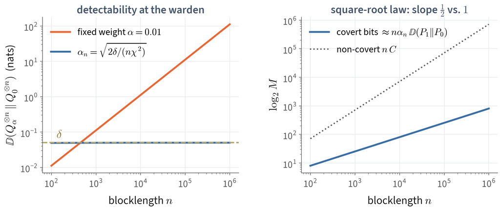

Willie: BSC(0.2) from the innocent symbol, $\chi^2(Q_1\|Q_0) = 2.25$; Bob: BSC(0.05); $\delta = 0.05$. Left: relative entropy at Willie. Right: covert bits from Theorem 1.

[figure not shown]

Random coding over **low-weight sequences**: codewords drawn i.i.d. from $\Pi_{\alpha_n}^{\otimes n}$, $\Pi_\alpha = \mathrm{Bernoulli}(\alpha)$, shown for $n = 64$ (counts on the right).

## Covert Communication: The Resolvability Perspective

Soft covering Covert Secure ISAC Synthesis Watermarking $X$: input, $0$ = innocent · $Y$: Bob · $Z$: Willie

\(\widehat Q^{n}\)

code-induced

\(Q_{\alpha_n}^{\otimes n}\)

covert process

\(Q_0^{\otimes n}\)

innocent

\(n\,\D(Q_{\alpha_n}\Vert Q_0) \approx \delta\)

resolvability  
\(\D(\widehat Q^n\Vert Q_{\alpha_n}^{\otimes n}) \to 0\)

covert: \(\D(\widehat Q^n\Vert Q_0^{\otimes n}) \le \delta + o(1)\)

- **Aim at the covert process** $Q_{\alpha_n}^{\otimes n}$ instead of $Q_0^{\otimes n}$ directly
- **Step 1 (no coding)**: $\alpha_n$ sets $\D(Q_{\alpha_n}^{\otimes n}\|Q_0^{\otimes n}) = n\,\D(Q_{\alpha_n}\|Q_0) \to \delta$
- **Step 2 (soft covering)**: low-weight random codes make $\widehat Q^n \approx Q_{\alpha_n}^{\otimes n}$
- **Glue: an exact identity**
  $$\begin{aligned}
  \D(\widehat Q^n\|Q_0^{\otimes n}) &= \D(Q_{\alpha_n}^{\otimes n}\|Q_0^{\otimes n}) + \D(\widehat Q^n\|Q_{\alpha_n}^{\otimes n}) \\
  &\quad + \textstyle\sum_{z^n}\big(\widehat Q^n - Q_{\alpha_n}^{\otimes n}\big)\log\frac{Q_{\alpha_n}^{\otimes n}}{Q_0^{\otimes n}}
  \end{aligned}$$
  - the last sum is at most $2\V(\widehat Q^n, Q_{\alpha_n}^{\otimes n}) \cdot O(n\alpha_n)$, since each letter of $\log\frac{Q_{\alpha}}{Q_0} = \log\big(1 + \alpha(\frac{Q_1}{Q_0} - 1)\big)$ is $O(\alpha)$
  - so step 2 must make the TV $o(1/(n\alpha_n)) = o(1/\sqrt n)$, which an exponent in $\sqrt n$ delivers

## Covert Communication: Information Densities at Low Weight

Soft covering Covert Secure ISAC Synthesis Watermarking $\Pi_\alpha = \mathrm{Bernoulli}(\alpha)$ · $Q_\alpha = (1-\alpha)Q_0 + \alpha Q_1$

- **An exact identity** for mutual information at weight $\alpha$:
  $$\I(\Pi_\alpha, W_{Z|X}) = \sum_x \Pi_\alpha(x)\, \D(Q_x \| Q_\alpha) = \alpha\,\D(Q_1\|Q_0) - \D(Q_\alpha\|Q_0) = \alpha\,\D(Q_1\|Q_0) + O(\alpha^2)$$
  - *proof*: write $\log\frac{Q_x}{Q_\alpha} = \log\frac{Q_x}{Q_0} - \log\frac{Q_\alpha}{Q_0}$ and average; likewise $\I(\Pi_\alpha, W_{Y|X}) = \alpha\,\D(P_1\|P_0) + O(\alpha^2)$ at Bob
- **The information density** $\;\imath_\alpha(X^n;Z^n) = \sum_{i=1}^n \log\frac{Q_{X_i}(Z_i)}{Q_\alpha(Z_i)}\;$ with $X^n \sim \Pi_{\alpha_n}^{\otimes n}$
  - mean $\;n\alpha_n\D(Q_1\|Q_0)\,(1 + o(1)) = \Theta(\sqrt n)$, variance $O(n\alpha_n)$, bounded summands when $Q_1 \ll Q_0$
- **Consequence**: the law of large numbers at scale $n$ is useless; Bernstein’s inequality gives tails $e^{-c\, n\alpha_n} = e^{-c'\sqrt n}$
  - every rate is measured in units of $n\alpha_n = \sqrt{2n\delta / \chi^2(Q_1\|Q_0)}$, and every exponent is in $\sqrt n$

Lemmas 1 and 2 carry over unchanged; only the concentration step is rescaled from $n$ to $n\alpha_n$.

## Covert Communication: Resolvability over Low-Weight Sequences

Soft covering Covert Secure ISAC Synthesis Watermarking $\Pi_\alpha = \mathrm{Bernoulli}(\alpha)$ · $Q_\alpha = (1-\alpha)Q_0 + \alpha Q_1$

Let the $MK$ codewords be i.i.d. $\Pi_{\alpha_n}^{\otimes n}$ with $\alpha_n \to 0$ and $n\alpha_n / \log n \to \infty$. If $\log(MK) \ge (1+\xi)\, n\alpha_n\D(Q_1\|Q_0)$ for some $\xi > 0$, then for some $c > 0$
$$\E_{\mathcal C}\, \D\big(\widehat Q^n \,\big\|\, Q_{\alpha_n}^{\otimes n}\big) \le e^{-c\, n\alpha_n}.$$

Apply Lemma 2(b) with $MK$ codewords, target $Q_{\alpha_n}^{\otimes n}$, and $\gamma = (1 + \xi/2)\, n\alpha_n\D(Q_1\|Q_0)$; the minimum mass of the target is $\mu_n^n$ with $\mu_n = \min_z Q_{\alpha_n}(z)$.
$$\E_{\mathcal C}\, \D\big(\widehat Q^n \,\big\|\, Q_{\alpha_n}^{\otimes n}\big) \le
\underbrace{\frac{e^{\gamma}}{MK}}_{\le\, e^{-\frac{\xi}{2} n\alpha_n \D(Q_1\|Q_0)}}
+ \underbrace{\Prob\big[\imath_\alpha(X^n;Z^n) > \gamma\big]}_{\text{Bernstein: } \le\, e^{-c\, n\alpha_n}} \cdot \underbrace{\big(1 + n\log\tfrac{1}{\mu_n}\big)}_{\text{polynomial in } n}$$
Since $\gamma$ exceeds the mean of $\imath_\alpha$ by $\Theta(n\alpha_n)$ and the variance is $O(n\alpha_n)$, the Bernstein exponent is $\Theta(n\alpha_n)$; $n\alpha_n \gg \log n$ absorbs the polynomial factor.

[12] M. R. Bloch, “Covert Communication over Noisy Channels: A Resolvability Perspective,” *IEEE Trans. Inf. Theory*, 2016.

## Covert Communication: Covert Capacity and the Key

Soft covering Covert Secure ISAC Synthesis Watermarking $P_x$: Bob’s output law · $Q_x$: Willie’s output law

If $Q_1 \ll Q_0$, $Q_1 \neq Q_0$ and $P_1 \ll P_0$, the largest number of covert bits with vanishing error satisfies
$$\lim_{n\to\infty} \frac{\log M}{\sqrt{n\delta}} = \sqrt{\frac{2}{\chi^2(Q_1\|Q_0)}}\; \D(P_1\|P_0),
\qquad \text{with key} \quad \log K \approx \sqrt{\frac{2n\delta}{\chi^2(Q_1\|Q_0)}}\, \big[\D(Q_1\|Q_0) - \D(P_1\|P_0)\big]^+ .$$

Willie, Lemma 3: \(\;\log MK > (1+\xi)\, n\alpha_n \D(Q_1\Vert Q_0)\)

\(m\): message

\(k\): key

codewords \(x^n(m,k)\)  
i.i.d. \(\Pi_{\alpha_n}^{\otimes n}\)

Bob knows \(k\), Lemma 1 rescaled: \(\;\log M < (1-\xi)\, n\alpha_n \D(P_1\Vert P_0)\)

with \(n\alpha_n = \sqrt{2n\delta/\chi^2(Q_1\Vert Q_0)}\) and the identity of the previous slides \(\;\Rightarrow\;\) Theorem 1

- **Converse** in two lines, with average weight $\bar\alpha_n$: $\;\delta \ge \D(\widehat Q^n\|Q_0^{\otimes n}) \ge \sum_i \D(\widehat Q_i\|Q_0) \ge n\,\D(Q_{\bar\alpha_n}\|Q_0) \approx \frac{n\bar\alpha_n^2}{2}\chi^2(Q_1\|Q_0)$, and Fano gives $\;\log M \lesssim n\,\I(\Pi_{\bar\alpha_n}, W_{Y|X}) \le n\bar\alpha_n\D(P_1\|P_0)$
- **No key** is needed when $\D(P_1\|P_0) > \D(Q_1\|Q_0)$: the message alone has enough randomness to cover Willie’s channel

[12] M. R. Bloch, “Covert Communication over Noisy Channels: A Resolvability Perspective,” *IEEE Trans. Inf. Theory*, 2016.

Part III

Secure Integrated Sensing and Communication

Hiding the structure of a state-dependent codebook from a sensing eavesdropper

## Secure ISAC: An Eavesdropper That Also Senses

Soft covering Covert Secure ISAC Synthesis Watermarking $S$: state · $X$: input · $Y_1$: Rx, fed back · $Y_2$: Eve

\(W\)

Tx

encode + sense

\(X_t\)

\(W_{Y_1Y_2|X,S}\)

state \(S\)

\(Y_1\)

Rx: \(\hat W\)

\(Y_2\)

Eve: \((\hat W, \hat S)\)

feedback \(Z_t = Y_{1,t-1}\)

\(\hat S\) at stopping time \(\tau\)

- **Tx** sends a message to Rx and **senses** the fixed state $S$ from feedback; it adapts its input type $P_{X,s}$ to the state estimate and stops at an LLR-based time $\tau$
- **Eve** observes $Y_2^\tau$ and wants **both** the message and the state; she knows all kernels and Tx’s public policy
- **Metrics**: secrecy rate $R$; Tx exponent $E_1 = -\frac1n\log P_{d_1}$ (large); Eve exponent $E_2 = -\frac1n\log P_{d_2}$ (small); strong secrecy $\max_s \I(W; Y_2^\tau) \le \delta$

**Tension**: adapting $P_{X,s}$ to the state helps Tx sense, and leaks the state to Eve through the statistics of the codebook.

[15] S. Guo, M. R. Bloch, “Secure Integrated Sensing and Communication against Communication and Sensing Eavesdropping,” arXiv:2601.23216, 2026.

## Secure ISAC: Where Soft Covering Enters: Eve Sees a Mixture

Soft covering Covert Secure ISAC Synthesis Watermarking $S$: state · $X$: input · $Y_1$: Rx, fed back · $Y_2$: Eve

- **Messages are key-protected**, so Eve’s likelihood for state $s$ is a mixture over the codebook $\mathcal C_s$ drawn from $P_{X,s}$
  $$p_s(y_2^n) = \frac{1}{|\mathcal C_s|}\sum_{x^n \in \mathcal C_s} W^{\otimes n}_{Y_2|X,s}(y_2^n \mid x^n)$$

**Resolvable at Eve**: codebook rate $\ge R_2(s) \triangleq \I(P_{X,s}; W_{Y_2|X,s})$

Soft covering: $p_s \approx \bar Q_s \triangleq (P_{X,s} \circ W_{Y_2|X,s})^{\otimes n}$. Eve tests two i.i.d. laws, with exponent
$$\Ch\big(P_{X,s}\circ W_{Y_2|X,s} \,\big\|\, P_{X,s'}\circ W_{Y_2|X,s'}\big)$$

**Not resolvable**: the mixture keeps the codebook’s structure

Eve can infer the codeword type and hence the state; Tx falls back to an open-loop type $P_{X,s} = P_X$, and Eve’s exponent is the conditional Chernoff information
$$\Ch\big(W_{Y_2|X,s} \,\big\|\, W_{Y_2|X,s'} \,\big|\, P_X\big)$$

- **Confusion strategy**: choose $\{P_{X,s}\}$ with $P_{X,s}\circ W_{Y_2|X,s} = P_{X,s'}\circ W_{Y_2|X,s'}$; the Chernoff information is $0$, so Tx adapts to the state while Eve’s sensing exponent vanishes (for BSCs, $P_{X,s}(0) = \frac12$ for all $s$ works)

[15] S. Guo, M. R. Bloch, “Secure Integrated Sensing and Communication against Communication and Sensing Eavesdropping,” arXiv:2601.23216, 2026.

## Secure ISAC: Soft Covering Must Beat Chernoff

Soft covering Covert Secure ISAC Synthesis Watermarking $\Gamma_s$: Eve’s code-induced law · $\bar Q_s$: its i.i.d. product approximation

If $\V(\Gamma_{s''}, \bar Q_{s''}) \le e^{-nE_{\SC}(P_{X,s''})}$ for $s'' \in \{s, s'\}$ and $\min_{s''} E_{\SC}(P_{X,s''}) > \Ch\big(P_{X,s}\circ W_{Y_2|X,s} \,\|\, P_{X,s'}\circ W_{Y_2|X,s'}\big)$, then the error of Eve’s best test between $s$ and $s'$ decays with exponent exactly this Chernoff information.

For any decision region $\mathcal A$, moving each law to its product approximation costs at most its TV:
$$\Big|\big[\Gamma_s(\mathcal A^c) + \Gamma_{s'}(\mathcal A)\big] - \big[\bar Q_s(\mathcal A^c) + \bar Q_{s'}(\mathcal A)\big]\Big| \le \V(\Gamma_s, \bar Q_s) + \V(\Gamma_{s'}, \bar Q_{s'}) \le 2e^{-n\min E_{\SC}}.$$
For i.i.d. hypotheses the minimum over $\mathcal A$ of the bracket is $e^{-n(\Ch + o(1))}$ (Chernoff [17]); the TV term is exponentially smaller.

- **Quantitative requirement**: TV must vanish *faster than the hypothesis-test error*, $E_{\SC} > \Ch$; “$\V \to 0$” alone is not enough
- **Exact soft-covering exponent** [8] (constant-composition codebook, rate $R \ge \I(P_X, W)$), which defines the resolvability region $\mathcal P_{\mathrm{res}}$ in [15]:
  $$E_{\SC}(P_X, W) = \min_{Q_{Y|X}} \Big\{\D(P_X Q_{Y|X} \| P_X W) + \tfrac12\big[R - \D(P_X Q_{Y|X} \| P_X Q_Y)\big]^+\Big\}$$

[8] S. Yagli, P. Cuff, “Exact Soft-Covering Exponent,” *IEEE Trans. Inf. Theory*, 2019. [15] S. Guo, M. R. Bloch, “Secure Integrated Sensing and Communication against Communication and Sensing Eavesdropping,” arXiv:2601.23216, 2026.  
[17] H. Chernoff, “A Measure of Asymptotic Efficiency for Tests of a Hypothesis Based on the Sum of Observations,” *Ann. Math. Stat.*, 1952.

## Secure ISAC: Feedback Keys Pay for Covering and for the One-Time Pad

Soft covering Covert Secure ISAC Synthesis Watermarking $R_1 = \I(P_{X,s};W_{Y_1|X,s})$ · $R_2 = \I(P_{X,s};W_{Y_2|X,s})$ · $R_{\mathrm{key}} = \Hent(Y_1|X,Y_2)$

- **Keys from feedback** at rate $R_{\mathrm{key}}(s) = \Hent(Y_1 \mid X, Y_2)$ [16]; in the regime $(R_2 - R_{\mathrm{key}})^+ < R_1 < R_2$, each block uses a codebook of rate $R_2$ drawn from $P_{X,\hat s}$:

whole codebook, rate \(R_2(s)\): resolvable at Eve, so the mixture looks i.i.d. and hides \(P_{X,s}\)

\(m \oplus r_2\) \(R_1 + R_{\mathrm{key}} - R_2\)

\(n\) \(R_2 - R_{\mathrm{key}}\)

\(r_1\) \(R_2 - R_1\)

key \(= (r_1, r_2)\):  
\(r_1\) covers, \(r_2\) pads

Rx knows \(r_1\) and decodes the rest at rate \(R_1(s)\)

secret message rate \([R_1 - R_2 + R_{\mathrm{key}}]^+\), with the state hidden whenever \(E_{\SC} > \Ch\)

| Regime | Scheme | Eve's state exponent |
| --- | --- | --- |
| \(R_1 \gt R_2\) | wiretap code with feedback keys | mixture Chernoff \(\Ch(P_{X,s}\circ W_s \Vert P_{X,s'}\circ W_{s'})\) |
| \((R_2 - R_{\mathrm{key}})^+ \lt R_1 \lt R_2\) | key split: resolvability (\(r_1\)) + one-time pad (\(r_2\)) | mixture Chernoff, if \(E_{\SC} \gt \Ch\) |
| \(R_1 \lt (R_2 - R_{\mathrm{key}})^+\) | all keys to the one-time pad, open-loop type \(P_X\) | conditional Chernoff \(\Ch(W_s \Vert W_{s'} \vert P_X)\) |

[16] R. Ahlswede, N. Cai, “Transmission, Identification and Common Randomness Capacities for Wire-Tape Channels with Secure Feedback from the Decoder,” *General Theory of Information Transfer and Combinatorics*, Springer, 2006.

## Secure ISAC: Achievable Region

Soft covering Covert Secure ISAC Synthesis Watermarking $R_1 = \I(P_{X,s};W_{Y_1|X,s})$ · $R_2 = \I(P_{X,s};W_{Y_2|X,s})$ · $R_{\mathrm{key}} = \Hent(Y_1|X,Y_2)$

The union over $\rho \in [0,1]$ and state-dependent types $\{P_{X,s}\}_{s\in\mathcal S}$ of all $(R, E_1, E_2)$ such that, for every $s$,
$$R \le \min\Big(\rho R_{\mathrm{key}}(s) + (1-\rho)\big[R_1(s) - R_2(s) + R_{\mathrm{key}}(s)\big]^+,\; R_1(s)\Big),
\qquad E_1 \le \min_{s' \neq s} \D\big(W_{Y_1|X,s} \,\|\, W_{Y_1|X,s'} \,\big|\, P_{X,s}\big),$$
$$E_2 \ge \min_{s'\neq s}
\begin{cases}
\rho\,\Ch\big(W_{Y_2|X,s} \| W_{Y_2|X,s'} \,|\, P_{X,s}\big) + (1-\rho)\,\Ch\big(P_{X,s}\circ W_{Y_2|X,s} \,\|\, P_{X,s'}\circ W_{Y_2|X,s'}\big) & \text{if } (P_{X,s}, P_{X,s'}) \in \mathcal P_{\mathrm{res}} \\[2pt]
\Ch\big(W_{Y_2|X,s} \| W_{Y_2|X,s'} \,|\, P_{X,s}\big) & \text{otherwise}
\end{cases}$$
is achievable, where $\mathcal P_{\mathrm{res}}$ requires $R_1 - R_2 + R_{\mathrm{key}} \ge 0$ and $\Ch\big(P_{X,s}\circ W_{Y_2|X,s} \| P_{X,s'}\circ W_{Y_2|X,s'}\big) < \min_{s''\in\{s,s'\}} E_{\SC}(P_{X,s''}, W_{Y_2|X,s''})$.

| \((1-\rho)\,\Ch(P_{X,s}\circ W \Vert P_{X,s'}\circ W')\) | fraction of time soft covering hides the codebook: Eve tests products (Lemma 4) |
| --- | --- |
| \(\rho\,\Ch(W \Vert W' \vert P_{X,s})\) | fraction of time spent on pure one-time pad: higher rate \(R_{\mathrm{key}}\), but codewords are not covered |
| \(\mathcal P_{\mathrm{res}}\) | enough randomness to cover (\(R_1 + R_{\mathrm{key}} \ge R_2\)), and covering faster than sensing (\(E_{\SC} \gt \Ch\)) |

- **Takeaway**: with the confusion strategy and resolvability, Tx reaches its sensing-secure operating point even when Eve’s channel is stronger than Rx’s

[15] S. Guo, M. R. Bloch, “Secure Integrated Sensing and Communication against Communication and Sensing Eavesdropping,” arXiv:2601.23216, 2026.

Part IV

Channel Synthesis

How much communication does it take to simulate a channel?

## Channel Synthesis: Simulating a Channel with Limited Communication

Soft covering Covert Secure ISAC Synthesis Watermarking $X$: source · $Y$: synthesized output · $U$: auxiliary

\(X^n \sim Q_X^{\otimes n}\)

Encoder

\(M \in [1:2^{nR}]\)

Decoder

\(Y^n\)

common randomness \(K \in [1:2^{nR_0}]\)

goal: \(\V\big(P_{X^nY^n},\, Q_{XY}^{\otimes n}\big) \to 0\)

$(R, R_0)$ synthesizes $Q_{Y|X}$ if and only if, for some $U$ with $X - U - Y$,
$$R \ge \I(X;U), \qquad R + R_0 \ge \I(X,Y;U).$$

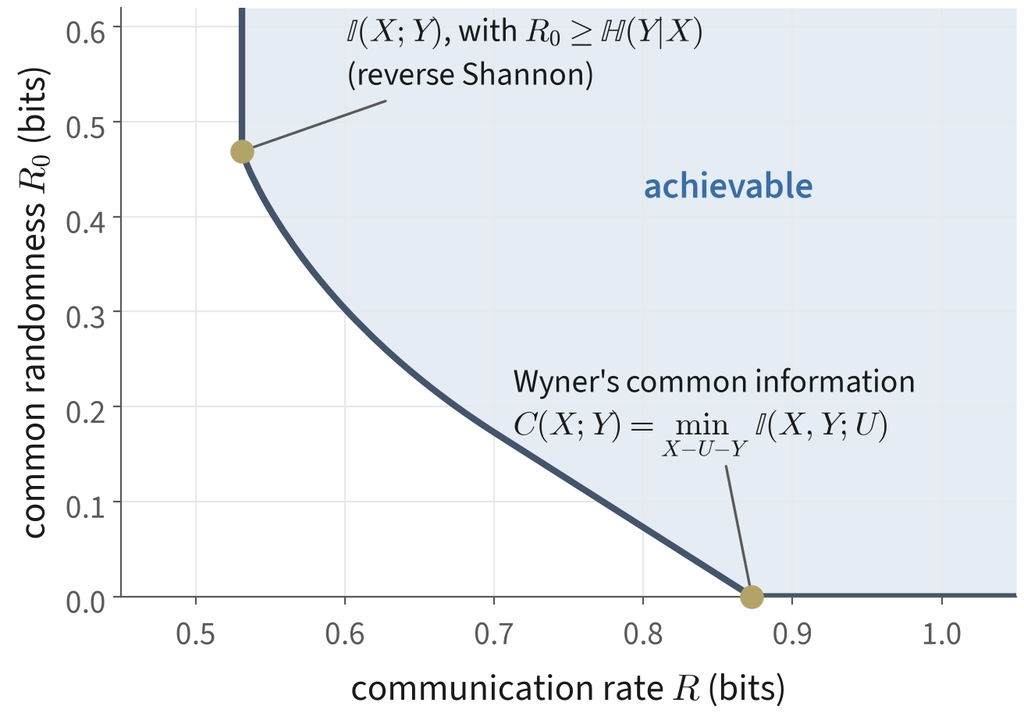

$Q_X = \mathrm{Bernoulli}(\frac12)$ and $Q_{Y|X}$ a BSC(0.1). Boundary traced by $U \sim \mathrm{Bernoulli}(\frac12)$, $X = U \oplus A$, $Y = U \oplus B$; both endpoints are exact.

- **Two extremes**: unlimited common randomness gives $R = \I(X;Y)$, the reverse Shannon theorem [18, 19]; none gives Wyner’s common information $C(X;Y)$ [2], whose proof is the original soft-covering lemma

[2] A. D. Wyner, “The Common Information of Two Dependent Random Variables,” *IEEE Trans. Inf. Theory*, 1975. [5] P. Cuff, “Distributed Channel Synthesis,” *IEEE Trans. Inf. Theory*, 2013. [18] C. H. Bennett, P. W. Shor, J. A. Smolin, A. V. Thapliyal, “Entanglement-Assisted Capacity of a Quantum Channel and the Reverse Shannon Theorem,” *IEEE Trans. Inf. Theory*, 2002. [19] A. Winter, “Compression of Sources of Probability Distributions and Density Operators,” arXiv:quant-ph/0208131, 2002.

## Channel Synthesis: Achievability by Two Soft Coverings

Soft covering Covert Secure ISAC Synthesis Watermarking $X$: source · $Y$: synthesized output · $U$: auxiliary

\((M,K)\)

uniform

\(U^n = u^n(M,K)\)

codebook i.i.d. \(Q_U\)

\(Q_{X|U}^{\otimes n} \to X^n\)

\(Q_{Y|U}^{\otimes n} \to Y^n\)

ideal distribution \(\Gamma\): \(X^n\) and \(Y^n\) are independent given \((M,K)\)

\(R + R_0 \gt \I(X,Y;U)\)

\(m\), rate \(R\)

\(k\), rate \(R_0\)

row \(k\) fixed: \(R \gt \I(X;U)\)

1. **Cover $(X,Y)$** with all $2^{n(R+R_0)}$ codewords: $\;\Gamma_{X^nY^n} \approx Q_{XY}^{\otimes n}$
2. **Cover $X$** with row $k$ alone, for every $k$: $\;\Gamma_{X^nK} \approx Q_X^{\otimes n} \times \Unif(K)$
3. **Real code**: the encoder is the **likelihood encoder** $\Gamma_{M|X^nK}$ [21]; the decoder draws $Y^n \sim Q^{\otimes n}_{Y|U}(\cdot \mid u^n(M,K))$
   $$P = Q_X^{\otimes n}\,\Unif_K\, \Gamma_{M|X^nK}\, \Gamma_{Y^n|MK},
   \quad
   \Gamma = \Gamma_{X^nK}\, \Gamma_{M|X^nK}\, \Gamma_{Y^n|MK}$$
   so $P$ and $\Gamma$ differ only in their first factor: $\;\V(P, \Gamma) = \V\big(Q_X^{\otimes n}\Unif_K,\, \Gamma_{X^nK}\big)$
4. **Triangle inequality**: $\;\V\big(P_{X^nY^n}, Q_{XY}^{\otimes n}\big) \le \V(P, \Gamma) + \V\big(\Gamma_{X^nY^n}, Q_{XY}^{\otimes n}\big) \to 0$

**Ideal-distribution method**: write down $\Gamma$, check two soft-covering conditions, and read the encoder off $\Gamma$. Part V reuses this verbatim.

[21] E. C. Song, P. Cuff, H. V. Poor, “The Likelihood Encoder for Lossy Compression,” *IEEE Trans. Inf. Theory*, 2016.

## Channel Synthesis: Converse Sketch

Soft covering Covert Secure ISAC Synthesis Watermarking $X$: source · $Y$: synthesized output · $U$: auxiliary

- **Auxiliary** $U_t \triangleq (M, K, X^{t-1})$. Since the decoder sees only $(M,K)$, $\;Y^n \perp X^n \mid (M,K)$, so $X_t - U_t - Y_t$ holds
- **Communication rate**: $X^n$ is i.i.d. and independent of $K$, so
  $$nR \ge H(M) \ge \I(X^n; M \mid K) = \I(X^n; M, K) = \sum_{t=1}^n \I(X_t; M, K, X^{t-1}) = \sum_{t=1}^n \I(X_t; U_t)$$
- **Sum rate**: by the chain rule,
  $$n(R + R_0) \ge \I(X^nY^n; M, K) \ge \sum_{t=1}^n \I(X_tY_t; U_t) - \underbrace{\Big[\sum_{t=1}^n H(X_tY_t) - H(X^nY^n)\Big]}_{\le\, n\,g(\epsilon)}$$
  - the bracket vanishes for an i.i.d. law; $\V(P_{X^nY^n}, Q_{XY}^{\otimes n}) \le \epsilon$ and continuity of entropy bound it by $n\,g(\epsilon)$ with $g(\epsilon) \to 0$
- **Single-letterize** with a time-sharing variable $T$ and $U = (U_T, T)$; $(X_T, Y_T)$ is $\epsilon$-close to $Q_{XY}$, and continuity closes the gap as $\epsilon \to 0$
- **Strong coordination** [20]: the same region holds for synthesizing a joint law $Q_{XY}$ given the source, the coordination view used in Part V

[20] P. Cuff, H. H. Permuter, T. M. Cover, “Coordination Capacity,” *IEEE Trans. Inf. Theory*, 2010.

Part V

Covert Multi-bit LLM Watermarking

Distribution-preserving watermarking as channel synthesis with state

## LLM Watermarking: Covert Watermarking Is Channel Synthesis with State

Soft covering Covert Secure ISAC Synthesis Watermarking $S$: token distribution (state) · $X$: token · $U$: codeword symbol

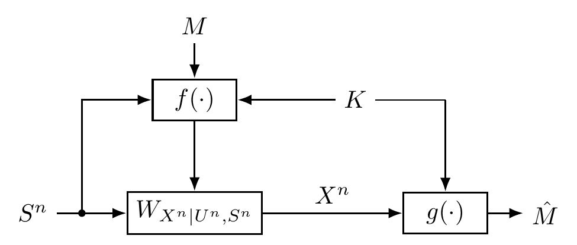

- **Encoder** sees the block of LLM states $S^n$, message $M$, key $K$: $\;U^n = f(S^n, M, K)$
- **Sampler** $W_{X|U,S}$ draws the tokens; **decoder** $\hat M = g(X^n, K)$
- **Covert for every message**: $\max_m \V\big(\widetilde P^{\,m}_{X^nS^n}, P_{XS}^{\otimes n}\big) \to 0$, with $P_{XS}$ the LLM’s own law

| Channel synthesis (Part IV) | Covert watermarking [22] |
| --- | --- |
| source \(X^n \sim Q_X^{\otimes n}\) | LLM states \(S^n \sim P_S^{\otimes n}\), seen non-causally by the encoder |
| synthesized output \(Y^n\) | tokens \(X^n\) |
| target \(Q_{XY}^{\otimes n}\) | the LLM's own law \(P_{XS}^{\otimes n}\): distribution preservation |
| common randomness \(K\) | secret key \(K\), shared with the detector |
| description index, rate \(R\) | likelihood-encoder index \(J\), rate \(R_0\) |
| no message | message \(M\), decoded from the tokens (Gelfand–Pinsker [23]) |
| target on average | target for **every** \(m\): semantic covertness [6] |

[6] P. Cuff, “A Stronger Soft-Covering Lemma and Applications,” IEEE CNS Workshops, 2015. [22] S. Guo, T. Kann, T. Baluta, M. R. Bloch, “Covert Multi-bit LLM Watermarking: An Information Theory and Coding Approach,” IEEE ITW, 2026.  
[23] S. I. Gel’fand, M. S. Pinsker, “Coding for Channel with Random Parameters,” *Probl. Control Inf. Theory*, 1980.

## LLM Watermarking: Covert Watermarking Capacity

Soft covering Covert Secure ISAC Synthesis Watermarking $S$: token distribution (state) · $X$: token · $U$: codeword symbol

With i.i.d. states $S^n \sim P_S^{\otimes n}$, the covert watermarking capacity with non-causal state is
$$C = \max_{P_{U|S},\, W_{X|U,S}} \I(U;X) - \I(U;S) \quad \text{s.t.} \quad \sum_u P_{UXS}(u,x,s) = P_{XS}(x,s),
\qquad \text{achieved with key rate } R_K = \I(U;X \mid S).$$

covertness for every \(m\), covered by \((k, j)\): \(\;R_K + R_0 > \mathbb{I}(U;X,S)\)

\(k\): key, \(R_K\)

\(j\): likelihood encoder, \(R_0\)

\(m\): message, \(R\)

soft covering of \(s^n\):  
\(R_0 > \mathbb{I}(U;S)\)

decoder resolves \((m, j)\): \(\;R + R_0 < \mathbb{I}(U;X)\)

\(\Rightarrow\;\; R < \mathbb{I}(U;X) - \mathbb{I}(U;S), \qquad R_K > \mathbb{I}(U;X,S) - \mathbb{I}(U;S) = \mathbb{I}(U;X \mid S)\)

| \(\I(U;X) - \I(U;S)\) | Gelfand–Pinsker rate: the codeword adapts to token distributions the decoder never sees |
| --- | --- |
| \(\sum_u P_{UXS} = P_{XS}\) | covertness: averaged over \(U\), the synthesized sampler is the LLM's own sampler |
| \(R_K = \I(U;X \mid S) = R + \I(U;S \mid X)\) | every message bit costs at least one key bit |

[22] S. Guo, T. Kann, T. Baluta, M. R. Bloch, “Covert Multi-bit LLM Watermarking: An Information Theory and Coding Approach,” IEEE ITW, 2026.

## LLM Watermarking: Where Each Soft Covering Is Used

Soft covering Covert Secure ISAC Synthesis Watermarking $S$: token distribution (state) · $X$: token · $U$: codeword symbol

1. **Codebook**: $2^{n(R_K + R + R_0)}$ codewords $u^n(k, m, j)$ drawn i.i.d. from $P_U$
2. **Likelihood encoder** [21]: draw $j \propto P^{\otimes n}_{S|U}\big(s^n \mid u^n(k,m,j)\big)$, then $x^n \sim W^{\otimes n}_{X|U,S}$; soft covering of $s^n$ by the $j$-index, with $R_0 > \I(U;S)$, makes the ideal and real distributions match, exactly as in step 3 of Part IV
3. **Covertness for every $m$**: soft covering of $(x^n, s^n)$ by the $(k,j)$-indices ($R_K + R_0 > \I(U;X,S)$), with the high-probability lemma [6] and a union bound over the $2^{nR}$ messages
4. **Reliability**: with the key, the decoder resolves $(m, j)$ by typicality ($R + R_0 < \I(U;X)$), a packing step
- **Converse**: Gelfand–Pinsker chaining with $U_i = (M, K, S_{i+1}^n, X^{i-1})$, plus TV continuity to turn covertness into $\I(M; X^n, S^n) = o(n)$; the same auxiliary bounds both rates, giving $R_K \ge \I(U;X|S) \ge R$
- **Beyond i.i.d. states**: LLM states have memory; information-spectrum versions of the same soft-covering conditions apply [22]

[6] P. Cuff, “A Stronger Soft-Covering Lemma and Applications,” IEEE CNS Workshops, 2015. [21] E. C. Song, P. Cuff, H. V. Poor, “The Likelihood Encoder for Lossy Compression,” *IEEE Trans. Inf. Theory*, 2016.  
[22] S. Guo, T. Kann, T. Baluta, M. R. Bloch, “Covert Multi-bit LLM Watermarking: An Information Theory and Coding Approach,” IEEE ITW, 2026.

## LLM Watermarking: Example: Binary Support

Soft covering Covert Secure ISAC Synthesis Watermarking $S$: token distribution (state) · $X$: token · $U$: codeword symbol

Let $|\mathcal X| = V$ and let the state $S$ be uniform over the $\binom{V}{2}$ token pairs, with $P_{X|S}(x \mid \{i,j\}) = \tfrac12$ for $x \in \{i,j\}$. Over binary auxiliaries $|\mathcal U| = 2$, the covert capacity is $\;R = \lfloor V^2/4 \rfloor \big/ \tbinom{V}{2} \to \tfrac12$ bit/token, with key rate $R_K = R$, achieved by a half/half labelling.

[figure not shown]

| split | free pairs | rate |
| --- | --- | --- |
| 1 \| 5 | 5 / 15 | 0.33 |
| 2 \| 4 | 8 / 15 | 0.53 |
| 3 \| 3 | 9 / 15 | 0.60 |

- Tokens are nodes, pair-states are edges; a one-bit label $u$ colours the nodes
- A **mixed-colour** edge is a free cell: $U$ can carry a bit while the token stays uniform on the pair
- A **same-colour** edge is stuck: covertness forces $U$ to carry nothing there
- The rate is the fraction of cut edges, maximized by a balanced split; for $V = 6$, $R = 9/15 = 0.6$
- ArcMark [24] reports a causal rate of $0.28$ on this example; non-causal state access raises the limit to $\frac12$

[24] A. Gilani, S. Vithana, C. X. Long, O. Kosut, L. Sankar, F. P. Calmon, “ArcMark: Distortion-Free Multi-Byte LLM Watermark via Optimal Transport,” NeurIPS, 2026.  
[25] M. R. Bloch, *Information-Theoretic Security: A Unified Treatment of Information-Theoretic Primitives and Algorithms*, draft v0.23, Georgia Institute of Technology, 2020.

## Summary: One Lemma, Five Index Splits

| Setting | Covered (soft covering) | Decoded (packing) | What covering buys |
| --- | --- | --- | --- |
| Wiretap [11] | row \(r\): \(R' \gt \I(X;Z)\) | \((m,r)\): \(R + R' \lt \I(X;Y)\) | strong secrecy |
| Covert [12] | \((m,k)\): \(\log MK \gt n\alpha_n\D(Q_1\Vert Q_0)\) | \(m\): \(\log M \lt n\alpha_n\D(P_1\Vert P_0)\) | undetectability; \(\Theta(\sqrt n)\) bits with weight \(\alpha_n \propto 1/\sqrt n\) |
| Secure ISAC [15] | whole block: rate \(R_2(s)\), with \(E_{\SC} \gt \Ch\) | \((m \oplus r_2, n)\): rate \(R_1(s)\) | hides the state-dependent type \(P_{X,s}\) from a sensing eavesdropper |
| Channel synthesis [5] | \((m,k)\): \(R + R_0 \gt \I(X,Y;U)\); row \(k\): \(R \gt \I(X;U)\) | none: the decoder simulates | strong coordination with the least communication |
| LLM watermarking [22] | \((k,j)\): \(R_K + R_0 \gt \I(U;X,S)\); \(j\): \(R_0 \gt \I(U;S)\) | \((m,j)\): \(R + R_0 \lt \I(U;X)\) | a watermark that preserves the LLM's distribution for every message |

- **Reliability** needs the codebook small enough to pack; **resolvability** needs parts of it large enough to cover
- **Scale matters**: $n$ for wiretap and synthesis, $n\alpha_n = \Theta(\sqrt n)$ for covertness, and an exponent race ($E_{\SC}$ vs. $\Ch$) for secure sensing
- **Strength matters**: high-probability soft covering turns “on average over messages” into “for every message”

## References

[1] C. E. Shannon, “Certain Results in Coding Theory for Noisy Channels,” *Information and Control*, 1957.  
[2] A. D. Wyner, “The Common Information of Two Dependent Random Variables,” *IEEE Trans. Inf. Theory*, 1975.  
[3] T. S. Han, S. Verdú, “Approximation Theory of Output Statistics,” *IEEE Trans. Inf. Theory*, 1993.  
[4] M. Hayashi, “General Nonasymptotic and Asymptotic Formulas in Channel Resolvability and Identification Capacity and Their Application to the Wiretap Channel,” *IEEE Trans. Inf. Theory*, 2006.  
[5] P. Cuff, “Distributed Channel Synthesis,” *IEEE Trans. Inf. Theory*, 2013.  
[6] P. Cuff, “A Stronger Soft-Covering Lemma and Applications,” IEEE CNS Workshops, 2015.  
[7] M. B. Parizi, E. Telatar, N. Merhav, “Exact Random Coding Secrecy Exponents for the Wiretap Channel,” *IEEE Trans. Inf. Theory*, 2017.  
[8] S. Yagli, P. Cuff, “Exact Soft-Covering Exponent,” *IEEE Trans. Inf. Theory*, 2019.  
[9] C. McDiarmid, “On the Method of Bounded Differences,” *Surveys in Combinatorics*, 1989.  
[10] A. D. Wyner, “The Wire-Tap Channel,” *Bell Syst. Tech. J.*, 1975.  
[11] M. R. Bloch, J. N. Laneman, “Strong Secrecy From Channel Resolvability,” *IEEE Trans. Inf. Theory*, 2013.  
[12] M. R. Bloch, “Covert Communication over Noisy Channels: A Resolvability Perspective,” *IEEE Trans. Inf. Theory*, 2016.  
[13] B. A. Bash, D. Goeckel, D. Towsley, “Limits of Reliable Communication with Low Probability of Detection on AWGN Channels,” *IEEE J. Sel. Areas Commun.*, 2013.  
[14] L. Wang, G. W. Wornell, L. Zheng, “Fundamental Limits of Communication with Low Probability of Detection,” *IEEE Trans. Inf. Theory*, 2016.  
[15] S. Guo, M. R. Bloch, “Secure Integrated Sensing and Communication against Communication and Sensing Eavesdropping,” arXiv:2601.23216, 2026.  
[16] R. Ahlswede, N. Cai, “Transmission, Identification and Common Randomness Capacities for Wire-Tape Channels with Secure Feedback from the Decoder,” *General Theory of Information Transfer and Combinatorics*, Springer, 2006.  
[17] H. Chernoff, “A Measure of Asymptotic Efficiency for Tests of a Hypothesis Based on the Sum of Observations,” *Ann. Math. Stat.*, 1952.  
[18] C. H. Bennett, P. W. Shor, J. A. Smolin, A. V. Thapliyal, “Entanglement-Assisted Capacity of a Quantum Channel and the Reverse Shannon Theorem,” *IEEE Trans. Inf. Theory*, 2002.  
[19] A. Winter, “Compression of Sources of Probability Distributions and Density Operators,” arXiv:quant-ph/0208131, 2002.  
[20] P. Cuff, H. H. Permuter, T. M. Cover, “Coordination Capacity,” *IEEE Trans. Inf. Theory*, 2010.  
[21] E. C. Song, P. Cuff, H. V. Poor, “The Likelihood Encoder for Lossy Compression,” *IEEE Trans. Inf. Theory*, 2016.  
[22] S. Guo, T. Kann, T. Baluta, M. R. Bloch, “Covert Multi-bit LLM Watermarking: An Information Theory and Coding Approach,” IEEE ITW, 2026.  
[23] S. I. Gel’fand, M. S. Pinsker, “Coding for Channel with Random Parameters,” *Probl. Control Inf. Theory*, 1980.  
[24] A. Gilani, S. Vithana, C. X. Long, O. Kosut, L. Sankar, F. P. Calmon, “ArcMark: Distortion-Free Multi-Byte LLM Watermark via Optimal Transport,” NeurIPS, 2026.  
[25] M. R. Bloch, *Information-Theoretic Security: A Unified Treatment of Information-Theoretic Primitives and Algorithms*, draft v0.23, Georgia Institute of Technology, 2020.